# Functions/Models with Data

# Informal Sensitivity Analysis

What happens when we vary parameters?

Informal - just try varying them

Helpful tools * looping/repeating

- in R - *purrr* package, also *apply* family of function
- classic *for* loops

If you need it a good source to review working with *purrr* to extract items from list and repeat operations

R description

[Useful Purrr Resource](https://www.rebeccabarter.com/blog/2019-08-19_purrr/)

# Rmarkdown code for informal sensitivity

```r
# lets try informal sensitivity analysis again, this time by varying efficiency if we don't know efficiency exactly , lets try 20 samples

# use map from purrr
# notice how map adds the one parameter that is missing from the input list
eff = rnorm(mean=0.6, sd = 0.1, n=20)
site2 = eff %>% map(~solarpv( area=0.1, solar=sierraczosolar, clr="green", eunit="W", g=FALSE, etype="direct", eff=.x ))

head(site2)
```

```
## [[1]]
## [[1]]$annual
## # A tibble: 11 × 2
##     year  elect
##    <int>  <dbl>
##  1  1944  8449.
##  2  1945 49270.
##  3  1946 55937.
##  4  1947 55221.
##  5  1948 51081.
##  6  1949 53032.
##  7  1950 53030.
##  8  1951 52407.
##  9  1952 50731.
## 10  1953 50245.
## 11  1954 41060.
##
## [[1]]$mean
## [1] 47314.84
##
##
## [[2]]
## [[2]]$annual
## # A tibble: 11 × 2
##     year  elect
##    <int>  <dbl>
##  1  1944 11503.
##  2  1945 67079.
##  3  1946 76156.
##  4  1947 75181.
##  5  1948 69544.
##  6  1949 72200.
##  7  1950 72197.
##  8  1951 71350.
##  9  1952 69067.
## 10  1953 68406.
## 11  1954 55901.
##
## [[2]]$mean
## [1] 64416.72
```

[output cut: 69 more lines]

```
##    <int>  <dbl>
##  1  1944 11516.
##  2  1945 67153.
##  3  1946 76240.
##  4  1947 75264.
##  5  1948 69620.
##  6  1949 72280.
##  7  1950 72277.
##  8  1951 71429.
##  9  1952 69144.
## 10  1953 68481.
## 11  1954 55963.
##
## [[6]]$mean
## [1] 64487.87
```

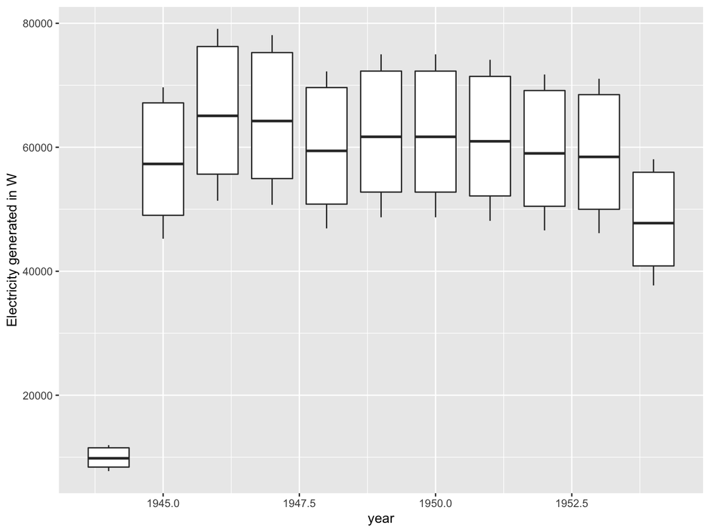

```r
# this is pretty messy - but we can extract a useful data structure,lets say we want
# just the annual data (not the mean annual time series), and then reformat as a data frame with nice column names
tmp = map_df(site2,`[`, c("annual"))

site2df = data.frame(year = tmp$annual$year, elect= tmp$annual$elect)

# now we could plot
ggplot(site2df, aes(year,elect, group=year ))+geom_boxplot()+labs(y="Electricity generated in W")
```

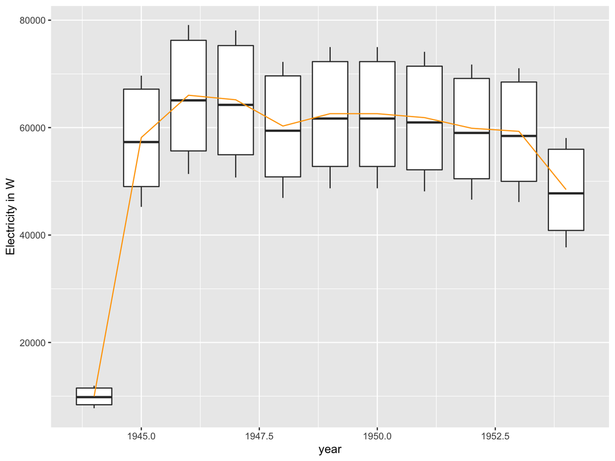

```r
# we also might want an average across parameter uncertainty
site2_average = site2df %>% group_by(year) %>% dplyr::summarize(elect=mean(elect))

# now add this to the plot - note that we remove the grouping by using group=1
ggplot(site2df, aes(year,elect, group=year))+geom_boxplot()+labs(y="Electricity in W")+
  geom_line(data=site2_average, aes(year, elect, group=1), col="orange")
```

```r
# we could also plot how the mean annual electricity varies with efficiency (eff from above)
site2[[1]]
```

```
## $annual
## # A tibble: 11 × 2
##     year  elect
##    <int>  <dbl>
##  1  1944  8449.
##  2  1945 49270.
##  3  1946 55937.
##  4  1947 55221.
##  5  1948 51081.
##  6  1949 53032.
##  7  1950 53030.
##  8  1951 52407.
##  9  1952 50731.
## 10  1953 50245.
## 11  1954 41060.
##
## $mean
## [1] 47314.84
```

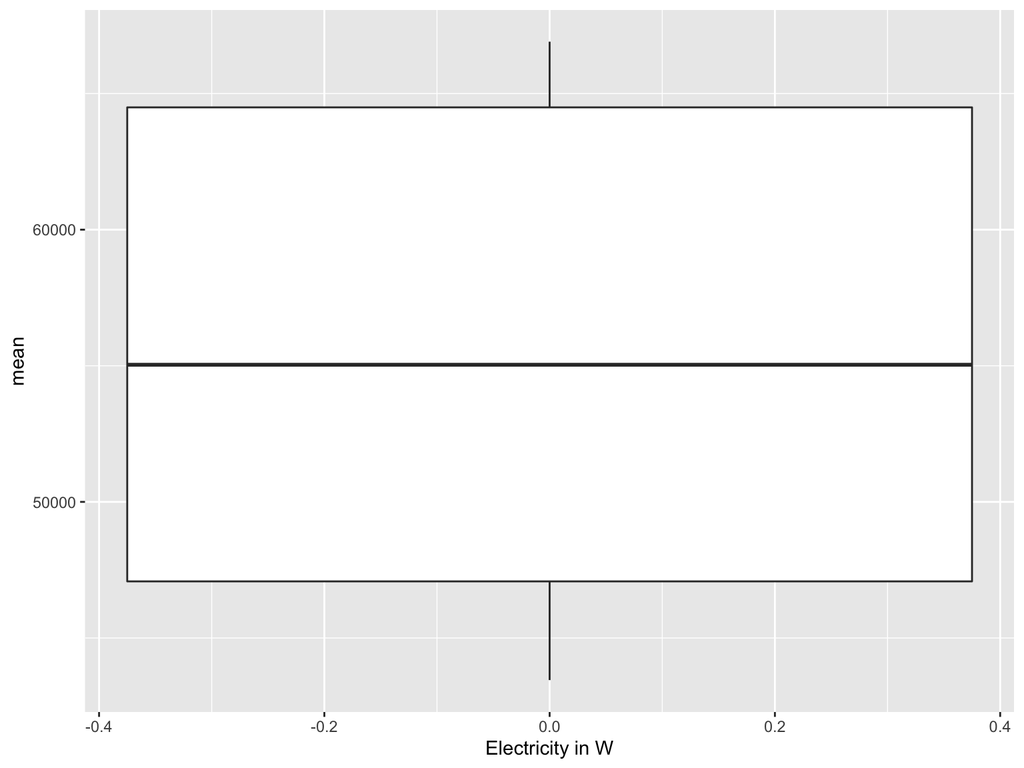

```r
tmp = map_df(site2,`[`, c("mean"))

# how variable is electricity generation (mean over all time) with uncertainty in solar efficiency

site2_mean = data.frame(eff=eff, elect= tmp)
ggplot(site2_mean, aes(y=mean))+geom_boxplot()+
  labs(x="Electricity in W")
```

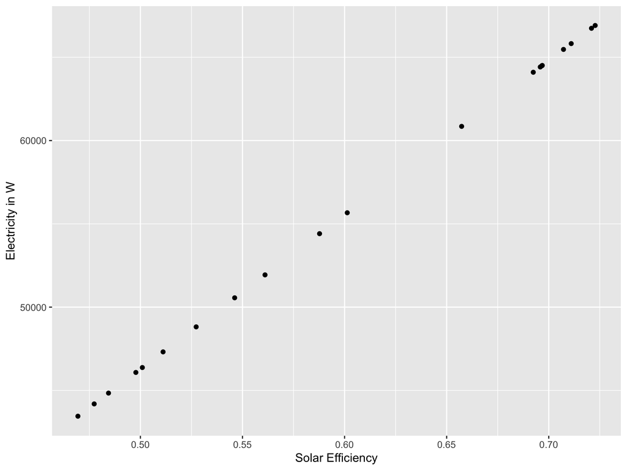

```r
# or to see what the sensitivity looks like
ggplot(site2_mean, aes(eff, mean))+geom_point()+
  labs(y="Electricity in W", x="Solar Efficiency")
```

# On your own, try the following

- Repeat an informal sensitivity analysis where instead of efficiency you vary the threshold solar radiation for power generation (note that the default value is 10000)
- Challenge - how would you do this with a *for* loop instead of *map* functions from *purrr*
- Challenge - how would you do an informal sensitivity analysis where you varied both efficiency and threshold

THURSDAY - CLASS IS ON ZOOM

Naomi Tague is inviting you to a scheduled Zoom meeting.

Join Zoom Meeting https://ucsb.zoom.us/j/82292927380

Meeting ID: 822 9292 7380